# Introduction to mixpoissonreg

Alexandre B. Simas

2020-12-30

# What is *mixpoissonreg* for?

The *mixpoissonreg* package is useful for fitting and analysing regression models with **overdispersed** count responses. It provides two regression models for overdispersed count data:

- Negative-Binomial regression models;
- Poisson Inverse Gaussian regression models.

The parameters of the above models may be estimated by the Expectation-Maximization algorithm or by direct maximization of the likelihood function.

There are several functions to aid the user to check the adequacy of the fitted model, perform some inference and study influential observations.

For theoretical details we refer the reader to [Barreto-Souza and Simas (2016)](https://doi.org/10.1007/s11222-015-9601-6)

# Why use the mixpoissonreg package?

Some reasons are:

- `glm`-like functions to fit and analyze fitted models
- Useful plots for fitted models available using `R`’s base graphics or `ggplot2`
- Estimation of parameters via EM-algorithm
- Easy to do inference on fitted models with help of `lmtest` package
- Regression structure for the precision parameter
- Several global and local influence measures implemented (along with corresponding plots)
- Compatibility with the `tidyverse`

We will now delve into the reasons above in more detail.

## `glm`-like functions to fit and analyze fitted models

If you know how to fit `glm` models then you already know how to fit `mixpoissonreg` models. You use a `formula` expression for the regression with respect to mean parameter:

```r
library(mixpoissonreg)

fit <- mixpoissonreg(daysabs ~ gender + math + prog, data = Attendance)
```

If you do not provide further arguments, the *mixpoissonreg* package will fit a *Negative-Binomial* model with a *log* link function for the mean estimated via EM-algorithm. Just like you would do with a `glm` fit, you can just type `fit` to get a simplified output of the fit, or get a summary, by typing `summary(fit)`:

```r
fit
```

```
#>
#> Negative Binomial Regression - Expectation-Maximization Algorithm
#>
#> Call:
#> mixpoissonreg(formula = daysabs ~ gender + math + prog, data = Attendance)
#>
#> Coefficients modeling the mean (with log link):
#>    (Intercept)     gendermale           math   progAcademic progVocational
#>    2.707563981   -0.211066195   -0.006235448   -0.424575877   -1.252812675
#> Coefficients modeling the precision (with identity link):
#> (Intercept)
#>    1.047289
```

```r
summary(fit)
```

```
#>
#> Negative Binomial Regression - Expectation-Maximization Algorithm
#>
#> Call:
#> mixpoissonreg(formula = daysabs ~ gender + math + prog, data = Attendance)
#>
#>
#> Pearson residuals:
#>      RSS      Min       1Q   Median       3Q      Max
#> 345.7857  -0.9662  -0.7356  -0.3351   0.3132   5.5512
#>
#> Coefficients modeling the mean (with  link):
#>                 Estimate Std.error z-value Pr(>|z|)
#> (Intercept)     2.707564  0.203069  13.333  < 2e-16 ***
#> gendermale     -0.211066  0.122373  -1.725   0.0846 .
#> math           -0.006235  0.002491  -2.503   0.0123 *
#> progAcademic   -0.424576  0.181772  -2.336   0.0195 *
#> progVocational -1.252813  0.201381  -6.221 4.94e-10 ***
#>
#> Coefficients modeling the precision (with  link):
#>             Estimate Std.error z-value Pr(>|z|)
#> (Intercept)   1.0473    0.1082   9.675   <2e-16 ***
#> ---
#> Signif. codes:  0 '***' 0.001 '**' 0.01 '*' 0.05 '.' 0.1 ' ' 1
#>
#> Efron's pseudo R-squared:  0.1854615
#> Number of iterations of the EM algorithm = 1
```

If you want to fit a Poisson Inverse Gaussian regression model, just set the `model` argument to `PIG`:

```r
fit_pig <- mixpoissonreg(daysabs ~ gender + math + prog, model = "PIG", data = Attendance)

summary(fit_pig)
```

```
#>
#> Poisson Inverse Gaussian Regression - Expectation-Maximization Algorithm
#>
#> Call:
#> mixpoissonreg(formula = daysabs ~ gender + math + prog, data = Attendance,
#>     model = "PIG")
#>
#>
#> Pearson residuals:
#>      RSS      Min       1Q   Median       3Q      Max
#> 276.4232  -0.8225  -0.6386  -0.3219   0.3038   5.4969
#>
#> Coefficients modeling the mean (with  link):
#>                 Estimate Std.error z-value Pr(>|z|)
#> (Intercept)     3.060166  0.227621  13.444  < 2e-16 ***
#> gendermale     -0.244078  0.129011  -1.892 0.058502 .
#> math           -0.007421  0.002641  -2.810 0.004951 **
#> progAcademic   -0.719714  0.193040  -3.728 0.000193 ***
#> progVocational -1.591909  0.215375  -7.391 1.45e-13 ***
#>
#> Coefficients modeling the precision (with  link):
#>             Estimate Std.error z-value Pr(>|z|)
#> (Intercept)   0.7323    0.1121   6.533 6.46e-11 ***
#> ---
#> Signif. codes:  0 '***' 0.001 '**' 0.01 '*' 0.05 '.' 0.1 ' ' 1
#>
#> Efron's pseudo R-squared:  0.1758126
#> Number of iterations of the EM algorithm = 20
```

There are also several standard methods implemented for `mixpoissonreg` fitted objects: `plot`, `residuals`, `vcov`, `influence`, `cooks.distance`, `hatvalues`, `predict`, etc.

A fitted `mixpoissonreg` object is compatible with the `lrtest`, `waldtest`, `coeftest` and `coefci` methods from the `lmtest` package, which, for instance, allows one to easily perform ANOVA-like tests for `mixpoissonreg` models.

We refer the reader to the Analyzing overdispersed count data with the *mixpoissonreg* package vignette for further details on fitting `mixpoissonreg` objects.

## Useful plots for fitted models available using `R`’s base graphics or `ggplot2`

Once you have a fitted `mixpoissonreg` object, say `fit`, you can easily produce useful plots by typing `plot(fit)`:

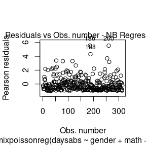

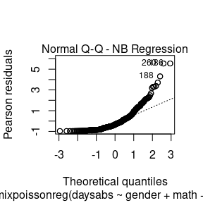

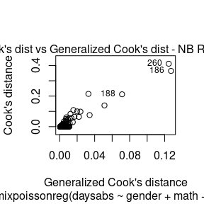

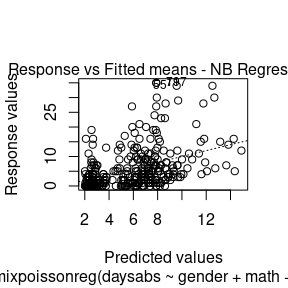

```r
plot(fit)
```

You can also have the `ggplot2` version of the above plots by typing `autoplot(fit)`:

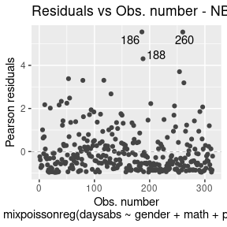

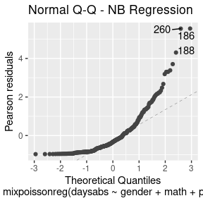

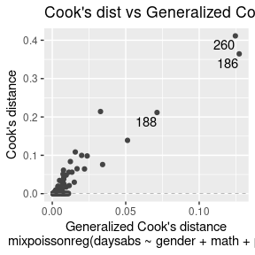

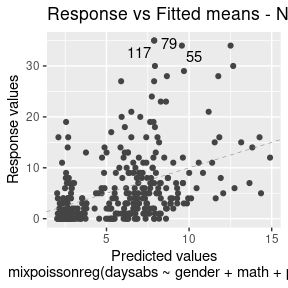

```r
autoplot(fit)
```

For further details on plots of `mixpoissonreg` objects, we refer the reader to the Diagnostic plots with the *mixpoissonreg* package vignette.

## Estimation of parameters via EM-algorithm

The EM-algorithm also tries to find the maximum-likelihood estimate of the parameters. So, why is there advantage on using the EM-algorithm? The reason is purely numerical. Sometimes the log-likelihood function has several local maxima or almost flat, which makes the direct maximization of the likelihood function converge (and making it very difficult not to obtain early convergence) before reaching its maximum. In such situations the EM-algorithm may be able to obtain estimates closer to the maximum-likelihood estimate. However, it has a drawback that it may take much longer to converge on such situations.

We refer the reader to the Supplementary Material of [Barreto-Souza and Simas (2016)](https://doi.org/10.1007/s11222-015-9601-6) and to [Barreto-Souza and Simas (2017)](https://doi.org/10.1080/00949655.2017.1350679) for numerical studies.

## Easy to do inference on fitted models with help of `lmtest` package

We can easily perform ANOVA-like tests using the `lmtest` package. Let us perform a likelihood-ratio test against the NULL model that only contains the intercept:

```r
lmtest::lrtest(fit)
```

```
#> Likelihood ratio test
#>
#> Model 1: daysabs ~ gender + math + prog | 1
#> Model 2: daysabs ~ 1 | 1
#>   #Df  LogLik Df  Chisq Pr(>Chisq)
#> 1   6 -864.15
#> 2   2 -896.47 -4 64.638  3.068e-13 ***
#> ---
#> Signif. codes:  0 '***' 0.001 '**' 0.01 '*' 0.05 '.' 0.1 ' ' 1
```

Now let us perform the Wald test against the NULL model that only contains the intercept:

```r
lmtest::waldtest(fit)
```

```
#> Wald test
#>
#> Model 1: daysabs ~ gender + math + prog | 1
#> Model 2: daysabs ~ 1 | 1
#>   Res.Df Df  Chisq Pr(>Chisq)
#> 1    308
#> 2    312 -4 74.257  2.861e-15 ***
#> ---
#> Signif. codes:  0 '***' 0.001 '**' 0.01 '*' 0.05 '.' 0.1 ' ' 1
```

Let us now consider a reduced model:

```r
fit_red <- mixpoissonreg(daysabs ~ math, data = Attendance)
```

We can perform a likelihood ratio test of full `fit` model against the NULL of the reduced model as:

```r
lmtest::lrtest(fit, fit_red)
```

```
#> Likelihood ratio test
#>
#> Model 1: daysabs ~ gender + math + prog | 1
#> Model 2: daysabs ~ math | 1
#>   #Df  LogLik Df  Chisq Pr(>Chisq)
#> 1   6 -864.15
#> 2   3 -888.15 -3 47.999  2.131e-10 ***
#> ---
#> Signif. codes:  0 '***' 0.001 '**' 0.01 '*' 0.05 '.' 0.1 ' ' 1
```

In the same fashion, we can perform a Wald test of full `fit` model against the NULL of the reduced model as:

```r
lmtest::waldtest(fit, fit_red)
```

```
#> Wald test
#>
#> Model 1: daysabs ~ gender + math + prog | 1
#> Model 2: daysabs ~ math | 1
#>   Res.Df Df  Chisq Pr(>Chisq)
#> 1    308
#> 2    311 -3 52.537  2.301e-11 ***
#> ---
#> Signif. codes:  0 '***' 0.001 '**' 0.01 '*' 0.05 '.' 0.1 ' ' 1
```

We can obtain confidence intervals for the estimated parameters by using the `coefci` method:

```r
lmtest::coefci(fit)
```

```
#>                             2.5 %       97.5 %
#> (Intercept)            2.30955534  3.105572621
#> gendermale            -0.45091355  0.028781163
#> math                  -0.01111851 -0.001352381
#> progAcademic          -0.78084150 -0.068310253
#> progVocational        -1.64751140 -0.858113947
#> (Intercept).precision  0.83512850  1.259450101
```

## Regression structure for the precision parameter

The `mixpoissonreg` package allows the regression models to also have a regression structure on the precision parameter. It is very simple to fit such models, one simply write the `formula` as `formula_1 | formula_2`, where `formula_1` corresponds to the regression structure with respect to the mean parameter and contains the response variable and `formula_2` corresponds to the regression structure with respect to the precision parameter and **does not** contain the response variable.

Consider the following example:

```r
fit_prec <- mixpoissonreg(daysabs ~ gender + math + prog | gender + math + prog,
                          data = Attendance)

summary(fit_prec)
```

```
#>
#> Negative Binomial Regression - Expectation-Maximization Algorithm
#>
#> Call:
#> mixpoissonreg(formula = daysabs ~ gender + math + prog | gender +
#>     math + prog, data = Attendance)
#>
#>
#> Pearson residuals:
#>      RSS      Min       1Q   Median       3Q      Max
#> 322.0142  -1.1751  -0.6992  -0.3600   0.3014   4.7178
#>
#> Coefficients modeling the mean (with  link):
#>                 Estimate Std.error z-value Pr(>|z|)
#> (Intercept)     2.746123  0.147412  18.629  < 2e-16 ***
#> gendermale     -0.245113  0.117967  -2.078  0.03773 *
#> math           -0.006617  0.002317  -2.856  0.00429 **
#> progAcademic   -0.425983  0.132144  -3.224  0.00127 **
#> progVocational -1.269755  0.174444  -7.279 3.37e-13 ***
#>
#> Coefficients modeling the precision (with  link):
#>                 Estimate Std.error z-value Pr(>|z|)
#> (Intercept)     1.414227  0.343243   4.120 3.79e-05 ***
#> gendermale     -0.208397  0.203692  -1.023 0.306262
#> math           -0.005123  0.004181  -1.225 0.220458
#> progAcademic   -1.084418  0.305479  -3.550 0.000385 ***
#> progVocational -1.422051  0.343812  -4.136 3.53e-05 ***
#> ---
#> Signif. codes:  0 '***' 0.001 '**' 0.01 '*' 0.05 '.' 0.1 ' ' 1
#>
#> Efron's pseudo R-squared:  0.1860886
#> Number of iterations of the EM algorithm = 11
```

In the abscence of `link.precision` argument, a *log* link will be used as link function for the precision parameter.

## Several global and local influence measures implemented (along with corresponding plots)

There are several global influence measures implemented. See `influence`, `hatvalues`, `cooks.distance` and their arguments.

The easiest way to perform global influence analysis on a `mixpoissonreg` fitted object is to obtain the plots related to global influence:

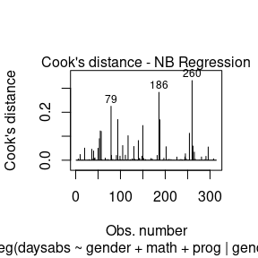

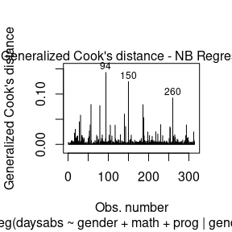

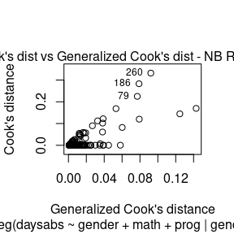

```r
plot(fit_prec, which = c(3,4,5))
```

One can also get the `ggplot2` version of the above plots:

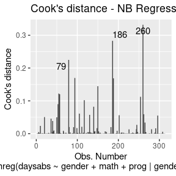

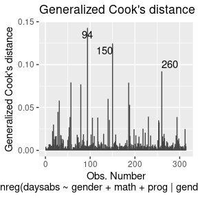

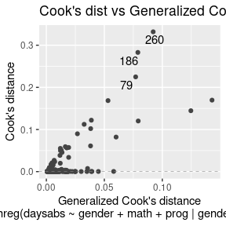

```r
autoplot(fit_prec, which = c(3,4,5))
```

In a similar fashion, there are several local influence measures implemented in the `local_influence` method. In the same spirit as above, the easiest way to perform local influence analysis on a `mixpoissonreg` fitted object is to obtain plots by using `local_influence_plot` method:

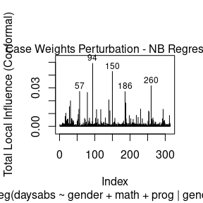

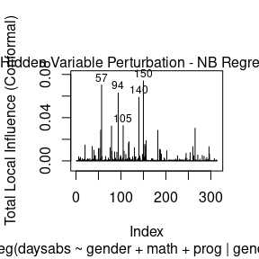

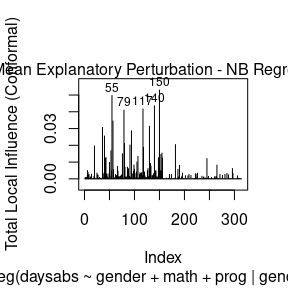

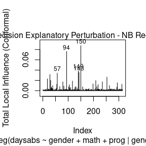

```r
local_influence_plot(fit_prec)
```

One can also obtain `ggplot2` versions of the above plots by using the `local_influence_autoplot` method:

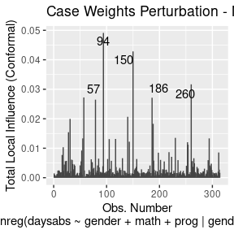

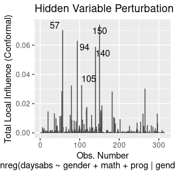

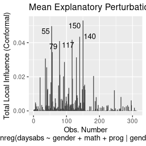

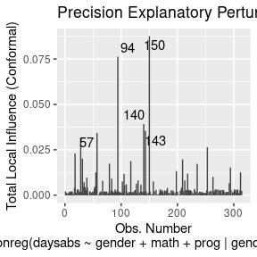

```r
local_influence_autoplot(fit_prec)
```

For further details on global and local influence analyses of `mixpoissonreg` objects, we refer the reader to the Global and local influence analysis with the *mixpoissonreg* package vignette.

## Compatibility with the `tidyverse`

We provide the standard methods from the `broom` package, namely `augment`, `glance` and `tidy`, for `mixpoissonreg` objects:

```r
augment(fit_prec)
```

```
#> # A tibble: 314 x 12
#>    daysabs gender  math prog  .fitted .fittedlwrconf .fitteduprconf .resid
#>      <dbl> <fct>  <dbl> <fct>   <dbl>          <dbl>          <dbl>  <dbl>
#>  1       4 male      63 Acad…    5.25           4.14           6.66 -0.200
#>  2       4 male      27 Acad…    6.66           5.40           8.22 -0.370
#>  3       2 female    20 Acad…    8.92           7.21          11.0  -0.814
#>  4       3 female    16 Acad…    9.15           7.34          11.4  -0.713
#>  5       3 female     2 Acad…   10.0            7.76          13.0  -0.772
#>  6      13 female    71 Acad…    6.36           5.02           8.07  0.956
#>  7      11 female    63 Acad…    6.71           5.39           8.34  0.599
#>  8       7 male       3 Acad…    7.81           6.04          10.1  -0.102
#>  9      10 male      51 Acad…    5.68           4.58           7.05  0.660
#> 10       9 male      49 Voca…    2.48           1.86           3.30  1.86
#> # … with 304 more rows, and 4 more variables: .resfit <dbl>, .hat <dbl>,
#> #   .cooksd <dbl>, .gencooksd <dbl>
```

```r
glance(fit_prec)
```

```
#> # A tibble: 1 x 9
#>   efron.pseudo.r2 df.null logLik   AIC   BIC df.residual  nobs model.type
#>             <dbl>   <dbl>  <dbl> <dbl> <dbl>       <int> <int> <chr>
#> 1           0.186     312  -853. 1726. 1764.         304   314 NB
#> # … with 1 more variable: est.method <chr>
```

```r
tidy(fit_prec)
```

```
#> # A tibble: 10 x 6
#>    component term           estimate std.error statistic  p.value
#>    <chr>     <chr>             <dbl>     <dbl>     <dbl>    <dbl>
#>  1 mean      (Intercept)     2.75      0.147       18.6  1.87e-77
#>  2 mean      gendermale     -0.245     0.118       -2.08 3.77e- 2
#>  3 mean      math           -0.00662   0.00232     -2.86 4.29e- 3
#>  4 mean      progAcademic   -0.426     0.132       -3.22 1.27e- 3
#>  5 mean      progVocational -1.27      0.174       -7.28 3.37e-13
#>  6 precision (Intercept)     1.41      0.343        4.12 3.79e- 5
#>  7 precision gendermale     -0.208     0.204       -1.02 3.06e- 1
#>  8 precision math           -0.00512   0.00418     -1.23 2.20e- 1
#>  9 precision progAcademic   -1.08      0.305       -3.55 3.85e- 4
#> 10 precision progVocational -1.42      0.344       -4.14 3.53e- 5
```

As seen above, the `autoplot` method from `ggplot2` package is also implemented for `mixpoissonreg` objects.

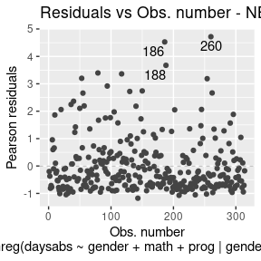

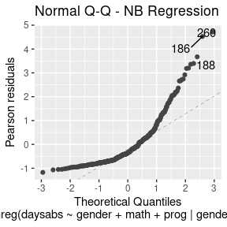

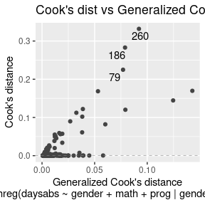

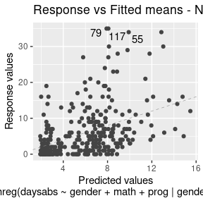

```r
autoplot(fit_prec)
```

Finally, we provide additional methods related to local influence analysis: `tidy_local_influence`, `local_influence_benchmarks` and `local_influence_autoplot`:

```r
tidy_local_influence(fit_prec)
```

```
#> # A tibble: 314 x 5
#>    case_weights hidden_variable mean_explanatory precision_expla…
#>           <dbl>           <dbl>            <dbl>            <dbl>
#>  1     0.00146         0.000353         0.000533         0.00217
#>  2     0.000970        0.000268         0.000782         0.00129
#>  3     0.000712        0.000369         0.000535         0.00132
#>  4     0.000350        0.000328         0.000875         0.000130
#>  5     0.000680        0.000562         0.00101          0.000701
#>  6     0.00118         0.00387          0.00494          0.000740
#>  7     0.00125         0.00230          0.00396          0.00139
#>  8     0.00243         0.00127          0.00230          0.00185
#>  9     0.00107         0.00180          0.00266          0.00160
#> 10     0.00249         0.00325          0.000340         0.000788
#> # … with 304 more rows, and 1 more variable: simultaneous_explanatory <dbl>
```

```r
local_influence_benchmarks(fit_prec)
```

```
#> # A tibble: 1 x 5
#>   case_weights hidden_variable mean_explanatory precision_expla…
#>          <dbl>           <dbl>            <dbl>            <dbl>
#> 1       0.0140          0.0206           0.0182           0.0195
#> # … with 1 more variable: simultaneous_explanatory <dbl>
```

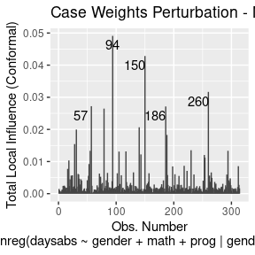

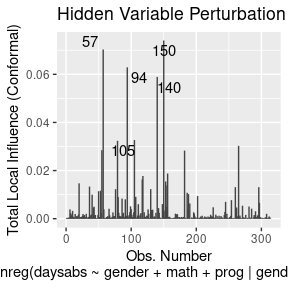

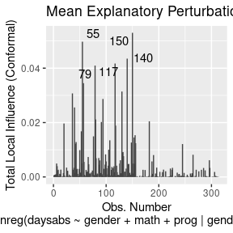

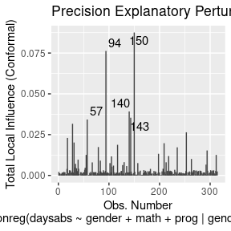

```r
local_influence_autoplot(fit_prec)
```

For further details on `tidyverse` compatibility of `mixpoissonreg` objects and how to use it to produce nice diagnostics and plots, we refer the reader to the *mixpoissonreg* in the *tidyverse* vignette.